# Data Mining Project

Rishika Dhody

December 22, 2017

## Final Project: Classifying jobs based on descriptions.

# Problem Statement

I have a dataset comprising of job descriptions. These jobs correspond to either beginner-level positions or positions requiring a high-level of experience. Classifying a job as **Beginner** or **Experienced** based on the job description is a partly subjective process. Some descriptions clearly state the amount of prior experience required, others clearly use words such as *junior* or *senior* in the descriptions, still others use words such as *familiar with* instead of *experienced with* to indicate that a position is for a relatively junior position.

Reading every job description and determining its classification can be a tedious process. The goal of this project is to find a classification model which can determine if a position is for an *experienced* or *beginner* candidate, based on the job description. A model is evaluated by the number of **correct classifications**.

I created this dataset when examining gender bias in the technology labor market. For this project, I start with a file containing the names of the job description files along with other information such as the gender of the applicant and the location of the job. These attributes are not relevant in the current context, since the goal of this project is to classify the job *before* applying to it. One could argue that the location of the job could be a contributing factor in the classification of interest however, this dataset was constructed with an equal number of Beginner and Experienced jobs for each city. Thus, reducing the significance of the location.

There are only **two** variables of interest from the original file - **Experience_Level** and **Description** (name of the file).

In the next few lines of code, I create a subset from the original data file. This subset comprises of entries which *have* a valid file associated with them. I use the files to create a corpus.

# Setup

Include the Final Project.Rmd file, Data Mining.xlsx file and the Job Descriptions.zip folder in the working directory.

```r
data <- read_excel("Data Mining.xlsx")
unzip("Job Descriptions.zip")

data <- data[, c("Description", "Experience_Level", "Valid")]

# Not all entries have a valid description file
data <- filter(data, Valid == "Y")
data$file_exists <- sapply(data$Description, function(x) {
                      file_name <- paste("Job Descriptions", x, sep = "/")
                      file.exists(file_name)
                     })

complete_data <- filter(data, file_exists == TRUE)
corpus.raw <- Corpus(DirSource(directory = "Job Descriptions"))
```

Cleaning up the corpus and creating the document term matrix.

An initial look at the corpus revealed some garbled words. Since the job descriptions were copied from HTML pages into rtf files, some formatting related text such as listid, fonttblffswissfcharset is found in the files. This text appears quite regularly throughout the files.

It could be possible that experienced job descriptions contain more bullet points, making HTML formatting text a contender as a valid independent variable. I tried the models both with and without the garbled words. I found that models performed marginally better without the garbled words. Therefore, I chose to remove them from the corpus.

Along with the stem words from the document term matrix at a sparsity of 0.7, I included the overall wordcount of the files as one of the independent variables.

```r
corpus <- tm_map(corpus.raw, content_transformer(tolower))
corpus <- tm_map(corpus, stripWhitespace)
corpus <- tm_map(corpus, removePunctuation)
corpus <- tm_map(corpus, removeNumbers)
corpus <- tm_map(corpus, removeWords, stopwords("english"))
corpus <- tm_map(corpus, stemDocument)
corpus <- tm_map(corpus, removeWords, c("deftab", "expndexpndtwkern", "marglmargrviewwviewhviewkind", "outlstrokewidth", "rtfansiansicpgcocoartfcocoasubrtf","strokec", "discleveltextleveltemplateiducu","kerningexpndexpndtw", "listtext", "listtablelistlisttemplateidlisthybridlistlevellevelnfclevelnfcnleveljcleveljcnlevelfollowlevelstartatlevelspacelevelindentlevelmark", "listnam", "listid", "levelnumbersfililin", "discleveltextleveltemplateiducu","listlisttemplateidlisthybridlistlevellevelnfclevelnfcnleveljcleveljcnlevelfollowlevelstartatlevelspacelevelindentlevelmark", "pardpardeftabslsa", "lsilvlcf", "colortblredgreenblueredgreenblueredgreenblu", "lsilvlcb", "ffs", "fbfs", "pardpardeftab", "fonttblffswissfcharset", "ucu","pardtxtxpardeftablifislsa", "listoverridetablelistoverridelistidlistoverridecountlslistoverridelistidlistoverridecountlslistoverridelistidlistoverridecountl"))

dtm <- DocumentTermMatrix(corpus)
dtms <- removeSparseTerms(dtm, sparse = 0.7)

dtm_tfidf <- weightTfIdf(dtms)
dtm_tfidf_mat  <- as.matrix(dtm_tfidf)
dtm_df <- as.data.frame(dtm_tfidf_mat)
dtm_df$word_count <- rowSums(as.matrix(dtm_df))

dtm_df$Description <- rownames(dtm_df)
```

Creating and formatting complete data set.

```r
# merge two data frames by description
complete_df <- merge(dtm_df, complete_data, by = "Description")
rownames(complete_df) <- complete_df$Description

remove_cols <- names(complete_df) %in% c("file_exists", "Description", "Location", "Valid", "Age", "time_sum", "Response", "Gender")
complete_df <- complete_df[!remove_cols]

complete_df$Experience_Level <- as.factor(complete_df$Experience_Level)
```

Splitting into testing and training. Creating multiple training and testing datasets. One including all the variables, another excluding the dependent variable and another converting the dependent variable from a factor to a number (0, 1). To be used for the PLSR model.

```r
in_train <- createDataPartition(y = complete_df$Experience_Level, p = 3 / 4, list = FALSE)
training_data <- complete_df[ in_train, ]
testing_data  <- complete_df[-in_train, ]

remove_dependent_var <- names(training_data) %in% c("Experience_Level")
training_data_bart <- training_data[!remove_dependent_var]

remove_dependent_var <- names(testing_data) %in% c("Experience_Level")
testing_data_bart <- testing_data[!remove_dependent_var]

training_data_pls <- training_data
training_data_pls$Experience_Level <- sapply(training_data_pls$Experience_Level, function(x){
  if(x == "Beginner"){
    return(0)
  }
  else{
    return(1)
  }
})
training_dataX_pls <- training_data_pls[!(names(training_data_pls) %in% c("Experience_Level"))]

testing_data_pls <- testing_data
testing_data_pls$Experience_Level <- sapply(testing_data_pls$Experience_Level, function(x){
  if(x == "Beginner"){
    return(0)
  }
  else{
    return(1)
  }
})
testing_dataX_pls <- testing_data_pls[!(names(testing_data_pls) %in% c("Experience_Level"))]

# Creating data frame to store the results
results <- data.frame()
```

# Logit Model

Trying a logit regression, first with all the variables. Without any interactions. The additional word_count field does not appear to contribute to be a significant variable.

```r
logit <- glm(Experience_Level ~ .,
             data = training_data, family = binomial(link = "logit"))
logit$coefficients
```

```
##  (Intercept)         abil         agil       applic        build
##     26.56606   2181.20767   -785.80526  11818.89551  28717.76094
##          can         code     collabor      complex       comput
##  -2712.52496  17370.49594  23752.53511   4709.32172 -10325.97459
##      continu         data        deliv       design      develop
## -27507.30374   2873.48372   7887.19522  -5349.37283  -4470.67230
##        engin       experi         help         high         look
## -16225.02464  10160.56083   6113.70359  -1634.98453  17975.61859
##      problem        relat      respons       scienc      softwar
##   8871.89313   3342.21222  -1559.11522    766.78655   3995.15675
##        solut         solv       system         team      technic
##  16129.58900   4516.32531   5810.71779 -18378.79111  -1858.29350
##    technolog         test         time   understand         will
##  -8729.58181  -8454.65360 -20559.34448  17623.19624 -28428.32298
##         work         year      benefit         busi     communic
##  37266.22907  -7328.67047 -15501.62030  15753.98083  -8681.55038
##      compani        degre       employ      environ        excel
##  13040.54785   4814.73980  -2285.70912  13145.26042 -10756.14893
##        great         grow       includ       integr        learn
##   2332.18350   2990.02329   8589.72754 -12467.06441  -4466.99515
##        manag          new          one       orient      passion
##  -9234.20382  -3502.09431  -1732.96156   9152.85224  -3940.89620
##        peopl      perform         plan      practic      product
##  16352.59988   2680.95582 -12533.86314  -8765.19809   7952.76320
##      project       provid      qualiti       requir         role
##   8515.02429 -13753.24470 -11289.15587  11573.13336   6653.95114
##        skill       strong         tool       across         base
## -10825.62006  14810.33196   -582.21547   6175.06043  -4218.64826
##     challeng        creat       cultur       custom       deploy
## -12180.80316 -23084.65547  -9818.73222   4016.17650   3756.15155
##       featur     industri   javascript     knowledg      languag
##   7175.73613  -2720.69086  -5804.47352   2105.39617  -3566.40057
##         need     opportun        organ     platform      process
##  -2338.23068 -16456.63457  12896.12375   1505.88957  -3375.76218
##      support        world         best    framework         java
##  -2467.55523  -7854.49435  12284.00162 -14170.31072  -9170.07630
##         join         lead         make          use          way
##  -9214.26358   4623.29541  -5004.70109    277.11364 -16346.73648
##          web         also  architectur       improv       mentor
##  -7697.10355   -533.36121   7499.30816  -4620.42420   2706.44232
##         part      program        scale       servic         take
##           NA           NA           NA           NA           NA
##         like         user         well        innov    implement
##           NA           NA           NA           NA           NA
##        youll      success   word_count
##           NA           NA           NA
```

```r
y_hat_logit <- predict(logit, newdata = testing_data, type = "response")
z_logit <- as.integer(y_hat_logit > 0.5)

results <- data.frame(model = "logit - additive model", results = mean((testing_data$Experience_Level == "Experienced") == (predict(logit, newdata = testing_data, type = "response") > 0.5)))
kable(table(testing_data$Experience_Level, z_logit), caption = "Logit Confusion Matrix")
```

Logit Confusion Matrix

|  | 0 | 1 |
| --- | --- | --- |
| Beginner | 10 | 4 |
| Experienced | 11 | 7 |

Trying a logit regression, with interaction variables. Adding interaction variables does not seem to improve/ change the logit results.

```r
logit_inter_var <- glm(Experience_Level ~ (.) ^ 2 + I(abil^2) + I(agil^2) + I(applic ^ 2) + I(build ^ 2) + I(can ^ 2) + I(code ^ 2) + I(collabor ^ 2) + I(complex ^ 2) + I(comput ^ 2) + I(continu ^ 2) + I(data ^ 2) + I(deliv ^ 2) + I(design ^ 2) + I(develop ^ 2) + I(engin ^ 2) + I(experi ^ 2) + I(help ^ 2) + I(high ^ 2) + I(look ^ 2) + I(problem ^ 2) + I(relat ^ 2) + I(relat ^ 2) + I(respons ^ 2) + I(scienc ^ 2) + I(softwar ^ 2) + I(solut ^ 2) + I(solv ^ 2) + I(system ^ 2) + I(team ^ 2) + I(technic ^ 2) + I(technolog ^ 2)+ I(test ^ 2) + I(time ^ 2) + I(understand ^ 2) + I(will ^ 2) + I(work ^ 2) + I(year ^ 2) + I(benefit ^ 2) + I(busi ^ 2) + I(communic ^ 2) + I(compani ^ 2) + I(degre ^ 2) + I(employ ^ 2) + I(environ ^ 2) + I(excel ^ 2) + I(great ^ 2) + I(great ^ 2) + I(great ^ 2) + I(grow ^ 2) +  I(includ ^ 2) + I(integr ^ 2) + I(learn ^ 2) + I(manag ^ 2) + I(new ^ 2) + I(one ^ 2) + I(orient ^ 2) + I(passion ^ 2) + I(peopl ^ 2) + I(perform ^ 2) + I(plan ^ 2) + I(practic ^ 2) + I(product ^ 2) + I(project ^ 2) + I(provid ^ 2) + I(qualiti ^ 2) + I(requir ^ 2) + I(role ^ 2) + I(skill ^ 2) + I(strong ^ 2) +  I(tool ^ 2) + I(across ^ 2) + I(base ^ 2) + I(challeng ^ 2) + I(creat ^ 2) + I(cultur ^ 2) + I(custom ^ 2) + I(deploy ^ 2) + I(featur ^ 2) + I(industri ^ 2) + I(javascript ^ 2) + I(knowledg ^ 2) + I(languag ^ 2) + I(need ^ 2) + I(opportun ^ 2) + I(organ ^ 2) + I(platform ^ 2) + I(process ^ 2) + I(support ^ 2) + I(world ^ 2) + I(best ^ 2) + I(framework ^ 2) + I(java ^ 2) + I(join ^ 2) + I(join ^ 2) + I(lead ^ 2) + I(make ^ 2) + I(use ^ 2) + I(way ^ 2) + I(web ^ 2) + I(also ^ 2) + I(architectur ^ 2) + I(improv ^ 2) + I(mentor ^2) + I(part ^ 2) + I(program ^ 2) + I(scale ^ 2) + I(servic ^ 2) + I(take ^ 2) + I(like ^ 2) + I(user ^ 2) + I(well ^ 2) + I(innov ^ 2) + I(implement ^ 2) + I(youll ^ 2) + I(success ^ 2) + I(word_count ^ 2), data = training_data, family = binomial(link = "logit"))

logit_inter_var$coefficients
```

```
##            (Intercept)                   abil                   agil
##               26.56606             2181.20767             -785.80526
##                 applic                  build                    can
##            11818.89551            28717.76094            -2712.52496
##                   code               collabor                complex
##            17370.49594            23752.53511             4709.32172
##                 comput                continu                   data
##           -10325.97459           -27507.30374             2873.48372
##                  deliv                 design                develop
##             7887.19522            -5349.37283            -4470.67230
##                  engin                 experi                   help
##           -16225.02464            10160.56083             6113.70359
##                   high                   look                problem
##            -1634.98453            17975.61859             8871.89313
##                  relat                respons                 scienc
##             3342.21222            -1559.11522              766.78655
##                softwar                  solut                   solv
##             3995.15675            16129.58900             4516.32531
##                 system                   team                technic
##             5810.71779           -18378.79111            -1858.29350
##              technolog                   test                   time
##            -8729.58181            -8454.65360           -20559.34448
##             understand                   will                   work
##            17623.19624           -28428.32298            37266.22907
##                   year                benefit                   busi
##            -7328.67047           -15501.62030            15753.98083
##               communic                compani                  degre
##            -8681.55038            13040.54785             4814.73980
##                 employ                environ                  excel
##            -2285.70912            13145.26042           -10756.14893
##                  great                   grow                 includ
##             2332.18350             2990.02329             8589.72754
##                 integr                  learn                  manag
##           -12467.06441            -4466.99515            -9234.20382
##                    new                    one                 orient
##            -3502.09431            -1732.96156             9152.85224
##                passion                  peopl                perform
##            -3940.89620            16352.59988             2680.95582
##                   plan                practic                product
##           -12533.86314            -8765.19809             7952.76320
```

[output cut: 4239 more lines]

```
##                     NA                     NA                     NA
##              user:well             user:innov         user:implement
##                     NA                     NA                     NA
##             user:youll           user:success        user:word_count
##                     NA                     NA                     NA
##             well:innov         well:implement             well:youll
##                     NA                     NA                     NA
##           well:success        well:word_count        innov:implement
##                     NA                     NA                     NA
##            innov:youll          innov:success       innov:word_count
##                     NA                     NA                     NA
##        implement:youll      implement:success   implement:word_count
##                     NA                     NA                     NA
##          youll:success       youll:word_count     success:word_count
##                     NA                     NA                     NA
```

```r
y_hat_logit_var <- predict(logit_inter_var, newdata = testing_data, type = "response")
z_logit_var <- as.integer(y_hat_logit_var > 0.5)

results <- rbind(results, data.frame(model = "logit - model with variable interaction", results = mean((testing_data$Experience_Level == "Experienced") == (predict(logit_inter_var, newdata = testing_data, type = "response") > 0.5))))
kable(table(testing_data$Experience_Level, z_logit_var), caption = "Logit with interaction Confusion Matrix")
```

Logit with interaction Confusion Matrix

|  | 0 | 1 |
| --- | --- | --- |
| Beginner | 10 | 4 |
| Experienced | 11 | 7 |

# Linear Discriminant Analysis (LDA) Model

```r
LDA <- lda(Experience_Level ~ . , data = training_data)
y_hat_LDA <- predict(LDA, newdata = testing_data)
z_LDA <- y_hat_LDA$class

results <- rbind(results, data.frame(model = "LDA", results = mean(testing_data$Experience_Level == z_LDA)))
kable(table(testing_data$Experience_Level, z_LDA), caption = "LDA Confusion Matrix")
```

LDA Confusion Matrix

|  | Beginner | Experienced |
| --- | --- | --- |
| Beginner | 10 | 4 |
| Experienced | 10 | 8 |

# Glmpath

```r
X <- model.matrix(logit)
y <- training_data$Experience_Level

path_glm <- glmpath(X, y == "Experienced", nopenalty.subset = 1, family = binomial(link = "logit"))
summary(path_glm)
```

```
## Call:
## glmpath(x = X, y = y == "Experienced", nopenalty.subset = 1,
##     family = binomial(link = "logit"))
```

```
##          Df     Deviance      AIC      BIC
## Step 1    2 1.376278e+02 141.6278 146.8381
## Step 2    3 1.312475e+02 137.2475 145.0630
## Step 3    4 1.304820e+02 138.4820 148.9027
## Step 5    5 1.254995e+02 135.4995 148.5253
## Step 7    6 1.234772e+02 135.4772 151.1082
## Step 10   7 1.156758e+02 129.6758 147.9120
## Step 12   8 1.150731e+02 131.0731 151.9145
## Step 15   9 1.125304e+02 130.5304 153.9769
## Step 16  10 1.121106e+02 132.1106 158.1623
## Step 18  11 1.099536e+02 131.9536 160.6104
## Step 20  12 1.074411e+02 131.4411 162.7031
## Step 21  13 1.019365e+02 127.9365 161.8037
## Step 23  14 9.433338e+01 122.3334 158.8058
## Step 25  15 9.230747e+01 122.3075 161.3850
## Step 26  16 8.963357e+01 121.6336 163.3163
## Step 28  17 8.913163e+01 123.1316 167.4195
## Step 29  18 8.779905e+01 123.7991 170.6921
## Step 31  19 8.775175e+01 125.7517 175.2500
## Step 32  20 8.417570e+01 124.1757 176.2791
## Step 34  21 8.265215e+01 124.6521 179.3607
## Step 36  22 8.161592e+01 125.6159 182.9297
## Step 38  23 8.137414e+01 127.3741 187.2931
## Step 40  24 8.006133e+01 128.0613 190.5854
## Step 42  25 7.946610e+01 129.4661 194.5954
## Step 43  26 7.941937e+01 131.4194 199.1538
## Step 46  27 7.691437e+01 130.9144 201.2540
## Step 48  28 7.530047e+01 131.3005 204.2452
## Step 51  29 7.151616e+01 129.5162 205.0661
## Step 53  30 7.038323e+01 130.3832 208.5383
## Step 54  31 6.916963e+01 131.1696 211.9299
## Step 56  32 6.785573e+01 131.8557 215.2212
## Step 58  33 6.717161e+01 133.1716 219.1422
## Step 61  34 6.335097e+01 131.3510 219.9268
## Step 63  35 6.246224e+01 132.4622 223.6432
## Step 66  36 5.781891e+01 129.8189 223.6050
## Step 69  37 5.500732e+01 129.0073 225.3986
## Step 71  38 5.490027e+01 130.9003 229.8967
## Step 73  39 5.485457e+01 132.8546 234.4562
## Step 76  40 5.332155e+01 133.3215 237.5284
```

[output cut: 77 more lines]

```
## Step 227 83 8.395731e-04 166.0008 382.2300
## Step 228 84 8.384741e-04 168.0008 386.8351
## Step 230 85 8.012191e-04 170.0008 391.4403
## Step 231 86 7.012071e-04 172.0007 396.0453
## Step 232 87 6.985602e-04 174.0007 400.6505
## Step 233 88 6.729469e-04 176.0007 405.2556
## Step 234 89 6.650819e-04 178.0007 409.8608
## Step 235 90 6.589927e-04 180.0007 414.4660
## Step 236 91 6.517846e-04 182.0007 419.0711
## Step 237 92 6.242577e-04 184.0006 423.6763
## Step 238 93 6.106030e-04 186.0006 428.2814
## Step 239 94 6.049900e-04 188.0006 432.8866
## Step 240 95 6.024696e-04 190.0006 437.4918
## Step 241 96 5.799529e-04 192.0006 442.0969
## Step 242 97 5.582922e-04 194.0006 446.7021
```

```r
new_X <- model.matrix(logit, data = testing_data)
y_hat_path1 <- predict(path_glm, newx = new_X, type = "response", s = 125)
z_path1 <- as.integer(y_hat_path1 > 0.5)

results <- rbind(results, data.frame(model = "Glmpath", results = mean((testing_data$Experience_Level == "Experienced") ==
                                                                         (z_path1))))
kable(table(testing_data$Experience_Level, z_path1), caption = "Glmpath Confusion Matrix")
```

Glmpath Confusion Matrix

|  | 0 | 1 |
| --- | --- | --- |
| Beginner | 7 | 7 |
| Experienced | 3 | 15 |

# Rgenoud

```r
ll <- function(beta) {
  eta <- X %*% beta
  p <- 1 / (1 + exp(-eta))
  return( sum(dbinom(y == "yes", size = 1, prob = p, log = TRUE)) )
}
rgenoud <- genoud(fn = ll, nvars = ncol(X), max = TRUE,  print.level = 0)
y_hat_rgenoud <- rgenoud$par %*% t(new_X)
z_rgenoud <- as.integer(y_hat_rgenoud > 0.5)

results <- rbind(results, data.frame(model = "Rgenoud", results = mean((testing_data$Experience_Level == "Experienced")
                                                                       == (z_rgenoud))))
kable(table(testing_data$Experience_Level, z_path1), caption = "Rgenoud Confusion Matrix")
```

|  | 0 | 1 |
| --- | --- | --- |
| Beginner | 7 | 7 |
| Experienced | 3 | 15 |

# PLSR Model

Trying a PLSR Model with cross validation

```r
plsr <- plsR(dataY = training_data_pls$Experience_Level, dataX = training_dataX_pls, MClassed = TRUE, typeVC="standard")
```

```
## ____************************************************____
## ____TypeVC____ standard ____
## ____Component____ 1 ____
## ____Component____ 2 ____
## ____Predicting X without NA neither in X nor in Y____
```

```
## ****________________________________________________****
```

```r
y_hat_pls <- predict(plsr, newdata = testing_dataX_pls, type = "response")

z_pls <- as.integer(y_hat_pls > 0.5) # these are classifications

results <- rbind(results, data.frame(model = "PLSR", results = mean((testing_data$Experience_Level == "Experienced") == (z_pls))))
kable(table(testing_data_pls$Experience_Level, z_pls), caption = "PLSR Confusion Matrix")
```

PLSR Confusion Matrix

|  | 0 | 1 |
| --- | --- | --- |
| 0 | 9 | 5 |
| 1 | 3 | 15 |

# Trees

Trying a single tree, limited to 4 branches (based on trying upto 20 branches) to avoid over-fitting the data.

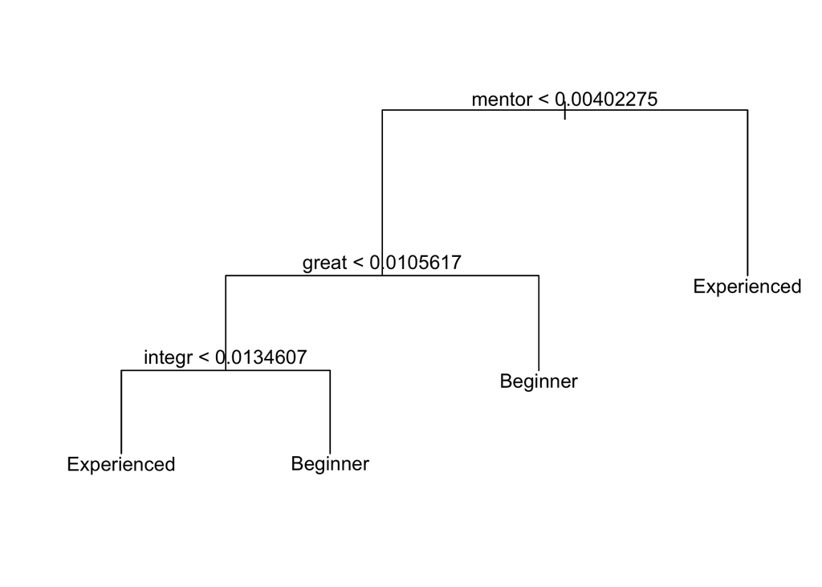

```r
out <- tree(Experience_Level ~ ., data = training_data)
best_model <- prune.tree(out, best = 4)
plot(best_model)
text(best_model, pretty = 0)
```

```r
predictions <- predict(best_model, newdata = testing_data, type = "class")
results <- rbind(results, data.frame(model = "Single Tree", results = mean(testing_data$Experience_Level == (predictions))))
kable(table(testing_data$Experience_Level, predictions), caption = "Single tree with pruning Confusion Matrix")
```

Single tree with pruning Confusion Matrix

|  | Beginner | Experienced |
| --- | --- | --- |
| Beginner | 9 | 5 |
| Experienced | 2 | 16 |

# Bagging Model

Trying the bagging model

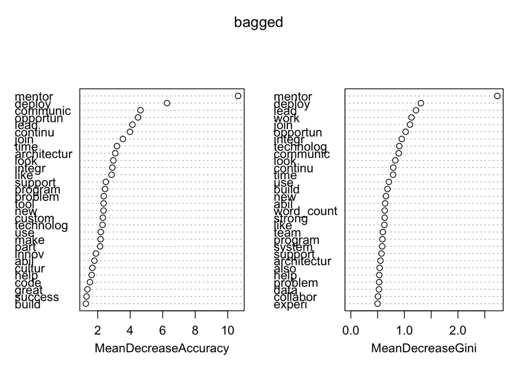

```r
bagged <- randomForest(Experience_Level ~ ., data = training_data,
                       mtr_y = ncol(training_data) - 1, importance = TRUE)
varImpPlot(bagged)
```

```r
exp_hat_bagged <- predict(bagged, newdata = testing_data, type = "class")
results <- rbind(results, data.frame(model = "Bagging", results = mean(testing_data$Experience_Level == (exp_hat_bagged))))
kable(table(testing_data$Experience_Level, exp_hat_bagged), caption = "Bagging Confusion Matrix")
```

Bagging Confusion Matrix

|  | Beginner | Experienced |
| --- | --- | --- |
| Beginner | 9 | 5 |
| Experienced | 3 | 15 |

# Random Forest

Trying Random Forest

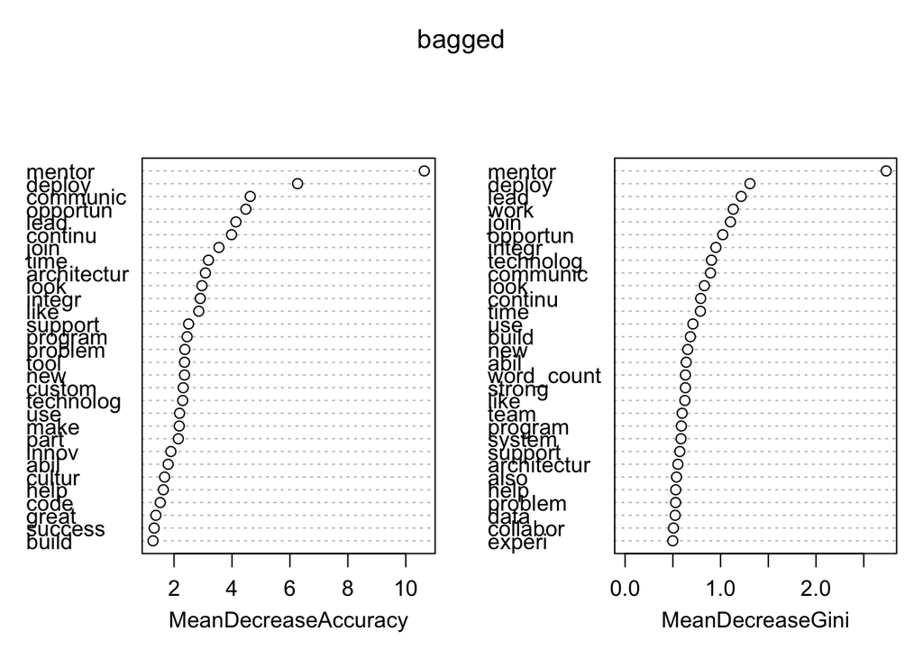

```r
rf <- randomForest(Experience_Level ~ ., data = training_data, importance = TRUE)
varImpPlot(bagged)
```

```r
exp_hat_rf <- predict(rf, newdata = testing_data, type = "class")
results <- rbind(results, data.frame(model = "Random Forest", results = mean(testing_data$Experience_Level == (exp_hat_rf))))
kable(table(testing_data$Experience_Level, exp_hat_rf), caption = "Random Forest Confusion Matrix")
```

Random Forest Confusion Matrix

|  | Beginner | Experienced |
| --- | --- | --- |
| Beginner | 10 | 4 |
| Experienced | 2 | 16 |

# Trying Bart Machine

Implementing classification using bayesian methods

```r
set_bart_machine_num_cores(parallel::detectCores())
```

```
## bartMachine now using 4 cores.
```

```r
bart <- bartMachine(X = training_data_bart, y = training_data$Experience_Level)
```

```
## bartMachine initializing with 50 trees...
## bartMachine vars checked...
## bartMachine java init...
## bartMachine factors created...
## bartMachine before preprocess...
## bartMachine after preprocess... 113 total features...
## warning: cannot use MSE of linear model for s_sq_y if p > n. bartMachine will use sample var(y) instead.
## bartMachine sigsq estimated...
## bartMachine training data finalized...
## Now building bartMachine for classification ...
## evaluating in sample data...done
```

```r
predictions_bart <- predict(bart, new_data = testing_data_bart, type = "class")
results <- rbind(results, data.frame(model = "Bart Machine", results = mean(testing_data$Experience_Level == (predictions_bart))))
kable(table(testing_data$Experience_Level, predictions_bart), caption = "Bart Machine Confusion Matrix")
```

Bart Machine Confusion Matrix

|  | Beginner | Experienced |
| --- | --- | --- |
| Beginner | 10 | 4 |
| Experienced | 3 | 15 |

# Boosting

Using the boosting model, assuming an additive model and the default shrinkage.

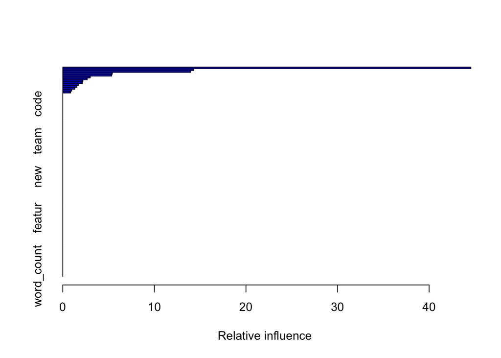

```
##                     var    rel.inf
## mentor           mentor 44.5660543
## deploy           deploy 14.3052932
## lead               lead 13.9606679
## opportun       opportun  5.4152413
## join               join  5.3431321
## look               look  3.0044382
## program         program  2.6714700
## like               like  2.1968248
## integr           integr  2.1481801
## time               time  1.7019297
## system           system  1.5434036
## one                 one  1.3129515
## work               work  0.9735823
## communic       communic  0.8568313
## abil               abil  0.0000000
## agil               agil  0.0000000
## applic           applic  0.0000000
## build             build  0.0000000
## can                 can  0.0000000
## code               code  0.0000000
## collabor       collabor  0.0000000
## complex         complex  0.0000000
## comput           comput  0.0000000
## continu         continu  0.0000000
## data               data  0.0000000
## deliv             deliv  0.0000000
## design           design  0.0000000
## develop         develop  0.0000000
## engin             engin  0.0000000
## experi           experi  0.0000000
## help               help  0.0000000
## high               high  0.0000000
## problem         problem  0.0000000
## relat             relat  0.0000000
## respons         respons  0.0000000
## scienc           scienc  0.0000000
## softwar         softwar  0.0000000
## solut             solut  0.0000000
## solv               solv  0.0000000
```

[output cut: 58 more lines]

```
## web                 web  0.0000000
## also               also  0.0000000
## architectur architectur  0.0000000
## improv           improv  0.0000000
## part               part  0.0000000
## scale             scale  0.0000000
## servic           servic  0.0000000
## take               take  0.0000000
## user               user  0.0000000
## well               well  0.0000000
## innov             innov  0.0000000
## implement     implement  0.0000000
## youll             youll  0.0000000
## success         success  0.0000000
## word_count   word_count  0.0000000
```

```r
boosted <- gbm(Experience_Level == "Experienced" ~ . , data = training_data, distribution = "bernoulli",
               interaction.depth = 1, shrinkage = 0.001,
               n.cores = parallel::detectCores())

summary(boosted)
```

```r
predictions <- predict(boosted, newdata = testing_data, type = "response",
                       n.trees = 100)
pred_boosting_def <- as.integer(predictions > 0.5)

results <- rbind(results, data.frame(model = "Boosting- additive model with default shrinkage", results = mean((testing_data$Experience_Level == "Experienced") == (pred_boosting_def))))
kable(table(testing_data$Experience_Level, pred_boosting_def), caption = "Boosting (defaults) Confusion Matrix")
```

Boosting (defaults) Confusion Matrix

|  | 1 |
| --- | --- |
| Beginner | 14 |
| Experienced | 18 |

The performance of the model improves on increasing the interaction depth and on increasing the shrinkage

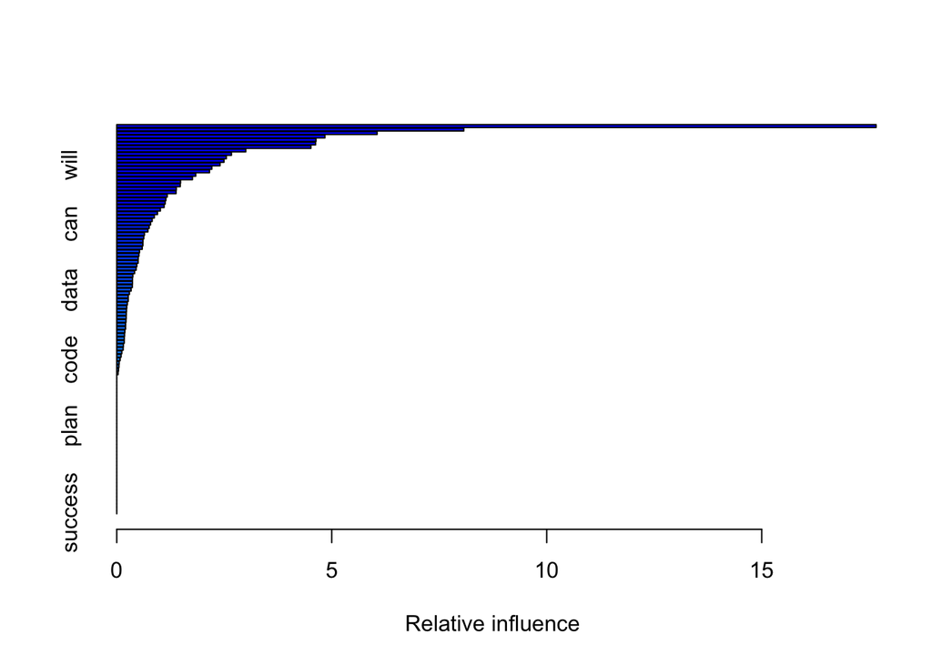

```
##                     var     rel.inf
## mentor           mentor 17.65977577
## deploy           deploy  8.07018877
## join               join  6.05445710
## look               look  4.84127984
## lead               lead  4.63330285
## communic       communic  4.62386016
## continu         continu  4.51498066
## employ           employ  3.00051978
## new                 new  2.66619737
## opportun       opportun  2.54816631
## use                 use  2.49236710
## will               will  2.40209770
## collabor       collabor  2.21071549
## work               work  2.15664769
## abil               abil  1.83692483
## integr           integr  1.76004784
## platform       platform  1.48356405
## program         program  1.47584195
## tool               tool  1.38516901
## like               like  1.37822563
## build             build  1.17399751
## across           across  1.14311684
## softwar         softwar  1.12624868
## develop         develop  1.10117928
## peopl             peopl  1.01418254
## architectur architectur  0.94689697
## time               time  0.87344581
## make               make  0.82372834
## can                 can  0.78681757
## product         product  0.75416014
## learn             learn  0.72423046
## busi               busi  0.64387650
## system           system  0.62878896
## manag             manag  0.60937775
## grow               grow  0.60696157
## great             great  0.59195621
## problem         problem  0.52905154
## degre             degre  0.51562544
## one                 one  0.49974232
```

[output cut: 58 more lines]

```
## languag         languag  0.00000000
## need               need  0.00000000
## organ             organ  0.00000000
## best               best  0.00000000
## framework     framework  0.00000000
## way                 way  0.00000000
## also               also  0.00000000
## improv           improv  0.00000000
## scale             scale  0.00000000
## servic           servic  0.00000000
## take               take  0.00000000
## user               user  0.00000000
## well               well  0.00000000
## innov             innov  0.00000000
## success         success  0.00000000
```

```r
boosted <- gbm(Experience_Level == "Experienced" ~ . , data = training_data, distribution = "bernoulli",
               interaction.depth = 7, shrinkage = 0.01,
               n.cores = parallel::detectCores())
summary(boosted)
```

```r
predictions <- predict(boosted, newdata = testing_data, type = "response",
                       n.trees = 100)
pred_boosting_custom <- as.integer(predictions > 0.5)
results <- rbind(results, data.frame(model = "Boosting- additive model with default shrinkage", results = mean((testing_data$Experience_Level == "Experienced") == (pred_boosting_custom))))
kable(table(testing_data$Experience_Level, pred_boosting_custom), caption = "Boosting (customized) Confusion Matrix")
```

Boosting (customized) Confusion Matrix

|  | 0 | 1 |
| --- | --- | --- |
| Beginner | 9 | 5 |
| Experienced | 2 | 16 |

# Neural Network

```r
for(units_hl in 1:7){
  nnet <- nnet(Experience_Level ~ ., data = training_data, size = units_hl, na.action = na.omit)
  Experience_Level_hat <- predict(nnet, newdata = testing_data, type = "class")
  results <- rbind(results, data.frame(model = paste("Neural Network, size =", units_hl), results = mean(testing_data$Experience_Level == (Experience_Level_hat))))
  print(kable(table(testing_data$Experience_Level, Experience_Level_hat)), caption = "Neural Network Confusion Matrix")
}
```

```
##
##
##                Beginner   Experienced
## ------------  ---------  ------------
## Beginner              8             6
## Experienced           3            15
##
##
##                Beginner   Experienced
## ------------  ---------  ------------
## Beginner              8             6
## Experienced           3            15
##
##
##                Beginner   Experienced
## ------------  ---------  ------------
## Beginner              7             7
## Experienced           3            15
##
##
##                Beginner   Experienced
## ------------  ---------  ------------
## Beginner              8             6
## Experienced           3            15
##
##
##                Beginner   Experienced
## ------------  ---------  ------------
## Beginner              8             6
## Experienced           3            15
##
##
##                Beginner   Experienced
## ------------  ---------  ------------
## Beginner              8             6
## Experienced           3            15
##
##
##                Beginner   Experienced
## ------------  ---------  ------------
## Beginner              8             6
## Experienced           2            16
```

# Comparing Models

```r
results
```

```
##                                              model results
## 1                           logit - additive model 0.53125
## 2          logit - model with variable interaction 0.53125
## 3                                              LDA 0.56250
## 4                                          Glmpath 0.68750
## 5                                          Rgenoud 0.43750
## 6                                             PLSR 0.75000
## 7                                      Single Tree 0.78125
## 8                                          Bagging 0.75000
## 9                                    Random Forest 0.81250
## 10                                    Bart Machine 0.78125
## 11 Boosting- additive model with default shrinkage 0.56250
## 12 Boosting- additive model with default shrinkage 0.78125
## 13                        Neural Network, size = 1 0.71875
## 14                        Neural Network, size = 2 0.71875
## 15                        Neural Network, size = 3 0.68750
## 16                        Neural Network, size = 4 0.71875
## 17                        Neural Network, size = 5 0.71875
## 18                        Neural Network, size = 6 0.71875
## 19                        Neural Network, size = 7 0.75000
```

Best Model on the correct classification critereon

```r
print(results[which.max(results$results),])
```

```
##           model results
## 9 Random Forest  0.8125
```

# Conclusion

The subjectivity of the classification is highlighted by the observation that the none of the models could yield more than a 82% success rate. The random forest model performs the best for the defined training dataset. The words *mentor*, *lead* and *deploy* appear to be the strongest indicators of an experienced position.